# PSTAT 131 Final Project

Matthew Bulygo

2022-06-07

# Introduction

In this project we will predict a video game’s sales in order to find out what types of video games will be successful.

## Why Does This Matter?

Video game companies are constantly innovating in order to stay successful and capture a wide audience. Finding out what types of games are popular will help them decide which games are worth creating.

## Loading Data and Packages

This project uses data from a [Kaggle data set](https://www.kaggle.com/datasets/rush4ratio/video-game-sales-with-ratings?resource=download). The original data set has more than 16,000 observations with 16 variables.

```r
# Load packages
set.seed(7)
library(readr)
library(tidyverse)
library(tidymodels)
library(patchwork)
library(janitor)
library(dplyr)
library(ggplot2)
library(corrplot)
```

```r
# Load dataset
original_videogame_data <- read_csv("videogame_data/Video_Games_Sales_as_at_22_Dec_2016.csv")
original_videogame_data
```

```
## # A tibble: 16,719 x 16
##    Name      Platform Year_of_Release Genre Publisher NA_Sales EU_Sales JP_Sales
##    <chr>     <chr>    <chr>           <chr> <chr>        <dbl>    <dbl>    <dbl>
##  1 Wii Spor~ Wii      2006            Spor~ Nintendo      41.4    29.0      3.77
##  2 Super Ma~ NES      1985            Plat~ Nintendo      29.1     3.58     6.81
##  3 Mario Ka~ Wii      2008            Raci~ Nintendo      15.7    12.8      3.79
##  4 Wii Spor~ Wii      2009            Spor~ Nintendo      15.6    10.9      3.28
##  5 Pokemon ~ GB       1996            Role~ Nintendo      11.3     8.89    10.2
##  6 Tetris    GB       1989            Puzz~ Nintendo      23.2     2.26     4.22
##  7 New Supe~ DS       2006            Plat~ Nintendo      11.3     9.14     6.5
##  8 Wii Play  Wii      2006            Misc  Nintendo      14.0     9.18     2.93
##  9 New Supe~ Wii      2009            Plat~ Nintendo      14.4     6.94     4.7
## 10 Duck Hunt NES      1984            Shoo~ Nintendo      26.9     0.63     0.28
## # ... with 16,709 more rows, and 8 more variables: Other_Sales <dbl>,
## #   Global_Sales <dbl>, Critic_Score <dbl>, Critic_Count <dbl>,
## #   User_Score <chr>, User_Count <dbl>, Developer <chr>, Rating <chr>
```

# Data Cleaning

We use clean_names() to make it easier to work with the data and get rid of observations with missing values. Our dataset now has around 7,000 observations.

```r
videogame_data <- original_videogame_data %>%
  clean_names()
videogame_data <- na.omit(videogame_data)
videogame_data$user_score <- as.numeric(as.character(videogame_data$user_score))
```

We’ll ignore na_sales, eu_sales, jp_sales, and other_sales and instead use global_sales to make analysis easier. We also get rid of developer since most people are only familiar with the publisher. Publishers also have lots of influence on video game developers so it will be more important to analyze the publishers.

```r
videogame_data <- videogame_data %>%
  select(-na_sales, -eu_sales, -jp_sales, -other_sales, -developer)
```

We’ll only be analyzing the six best selling publishers since we want the best performing ones. We have too many publishers which will hinder our analysis. The publishers in our analysis all have over ten million global sales. Our final data set has around 2000 observations and 11 variables.

```r
# Group data set by publisher and order by top selling publishers
publisher <- videogame_data %>%
  group_by(publisher) %>%
    filter(global_sales == max(global_sales))

publisher[1:10,] %>%
  select(publisher, global_sales)

publisher[1:6,] %>%
  select(publisher, global_sales)
```

```r
# Create new variable where top 6 publishers will equal 1. If a video game has a top_publisher = 1, then it will join the new data set.
videogame_data$top_publisher=0

videogame_data$top_publisher[(videogame_data$publisher=="Nintendo")| (videogame_data$publisher=="Activision")|
(videogame_data$publisher=="Sony Computer Entertainment")| (videogame_data$publisher=="Microsoft Game Studios")| (videogame_data$publisher=="Take-Two Interactive")| (videogame_data$publisher=="Ubisoft")]=1

videogame_final <- videogame_data[videogame_data$top_publisher==1,]
videogame_final <- videogame_final %>%
  select(-top_publisher)
videogame_final
```

```
## # A tibble: 2,019 x 11
##    name       platform year_of_release genre publisher global_sales critic_score
##    <chr>      <chr>    <chr>           <chr> <chr>            <dbl>        <dbl>
##  1 Wii Sports Wii      2006            Spor~ Nintendo          82.5           76
##  2 Mario Kar~ Wii      2008            Raci~ Nintendo          35.5           82
##  3 Wii Sport~ Wii      2009            Spor~ Nintendo          32.8           80
##  4 New Super~ DS       2006            Plat~ Nintendo          29.8           89
##  5 Wii Play   Wii      2006            Misc  Nintendo          28.9           58
##  6 New Super~ Wii      2009            Plat~ Nintendo          28.3           87
##  7 Mario Kar~ DS       2005            Raci~ Nintendo          23.2           91
##  8 Wii Fit    Wii      2007            Spor~ Nintendo          22.7           80
##  9 Kinect Ad~ X360     2010            Misc  Microsof~         21.8           61
## 10 Wii Fit P~ Wii      2009            Spor~ Nintendo          21.8           80
## # ... with 2,009 more rows, and 4 more variables: critic_count <dbl>,
## #   user_score <dbl>, user_count <dbl>, rating <chr>
```

# Exploratory Data Analysis

```r
genre <- videogame_final %>%
  group_by(genre) %>%
    filter(global_sales == max(global_sales))
genre
```

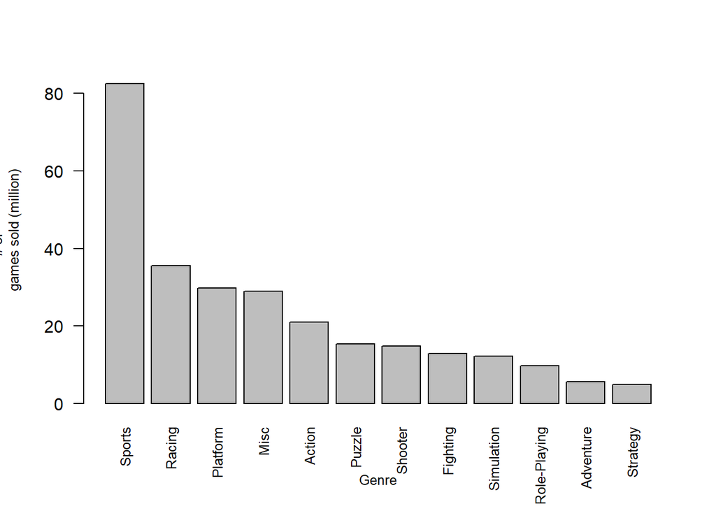

```r
barplot(genre$global_sales, names.arg = genre$genre, ylab="# of
        games sold (million)", xlab='Genre', las=2, cex.names=0.8,
        cex.lab=0.8)
```

The best selling genres are sports, racing, and platform.

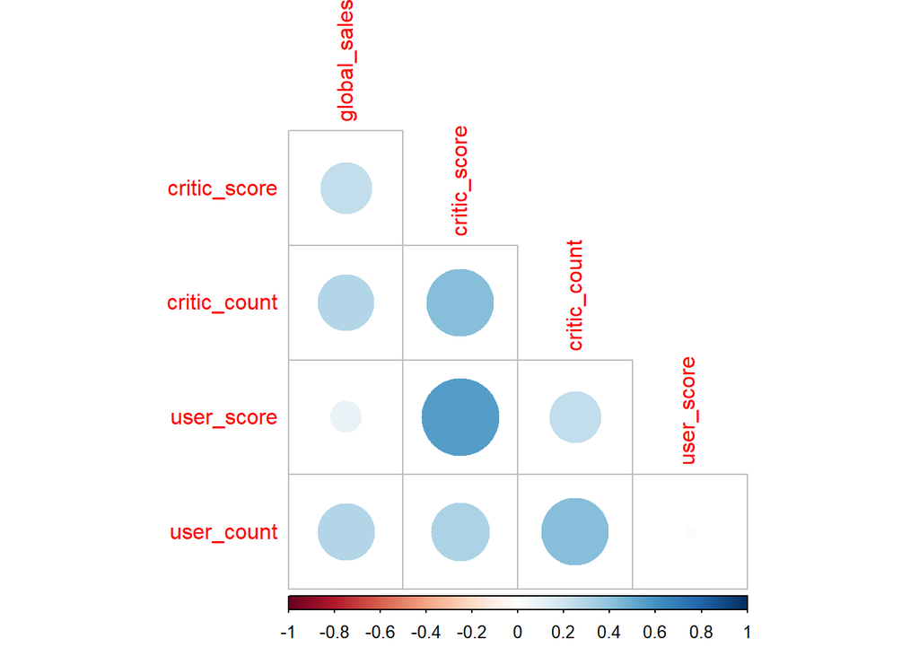

```r
videogame_final %>%
  select(is.numeric) %>%
  cor(use = "complete.obs") %>%
  corrplot(type = "lower", diag = FALSE)
```

Theres a positive correlation between user score and critic score.

# Model Building

## Splitting the Data

We split the data into training and test sets.

```r
videogame_split <- initial_split(videogame_final, prop=0.7, strata=global_sales)
videogame_train <- training(videogame_split)
videogame_test <- testing(videogame_split)

videogame_folds <- vfold_cv(videogame_train, v = 10, repeats = 5,
                            strata=global_sales)
```

## Creating the Recipe

```r
videogame_recipe <- recipe(global_sales ~ ., data = videogame_train) %>%
  step_dummy(all_nominal_predictors()) %>%
  step_normalize(all_predictors())
```

### Random Forest Model

```r
# Use regression since response is continuous
rf_model <-
  rand_forest(
              min_n = tune(),
              mtry = tune(),
              mode = "regression") %>%
  set_engine("ranger")

rf_workflow <- workflow() %>%
  add_model(rf_model) %>%
  add_recipe(videogame_recipe)
```

### Ridge Regression

```r
# Create recipe
ridge_recipe <-
  recipe(global_sales ~ ., data = videogame_train) %>%
  step_novel(all_nominal_predictors()) %>%
  step_dummy(all_nominal_predictors()) %>%
  step_zv(all_predictors()) %>%
  step_normalize(all_predictors())

ridge_spec <-
  linear_reg(penalty = tune(), mixture = 0) %>%
  set_mode("regression") %>%
  set_engine("glmnet")

ridge_workflow <- workflow() %>%
  add_recipe(videogame_recipe) %>%
  add_model(ridge_spec)

penalty_grid <- grid_regular(penalty(range = c(-5, 5)), levels = 50)
penalty_grid

tune_res1 <- tune_grid(
  ridge_workflow,
  resamples = videogame_folds,
  grid = penalty_grid
)

autoplot(tune_res1)

save(tune_res1, ridge_workflow, file = "model_fitting/tune_res1.rda")
```

### Lasso Regression

```r
lasso_recipe <-
  recipe(global_sales ~ ., data = videogame_train) %>%
  step_novel(all_nominal_predictors()) %>%
  step_dummy(all_nominal_predictors()) %>%
  step_zv(all_predictors()) %>%
  step_normalize(all_predictors())

lasso_spec <-
  linear_reg(penalty = tune(), mixture = 1) %>%
  set_mode("regression") %>%
  set_engine("glmnet")

lasso_workflow <- workflow() %>%
  add_recipe(lasso_recipe) %>%
  add_model(lasso_spec)

penalty_grid <- grid_regular(penalty(range = c(-2, 2)), levels = 50)

tune_res2 <- tune_grid(
  lasso_workflow,
  resamples = videogame_folds,
  grid = penalty_grid
)

autoplot(tune_res2)

save(tune_res2, lasso_workflow, file = "model_fitting/tune_res2.rda")
```

## Model Analysis

We load our saved results.

```r
load("model_fitting/tune_res1.rda")
load("model_fitting/tune_res2.rda")
```

### Ridge Regression

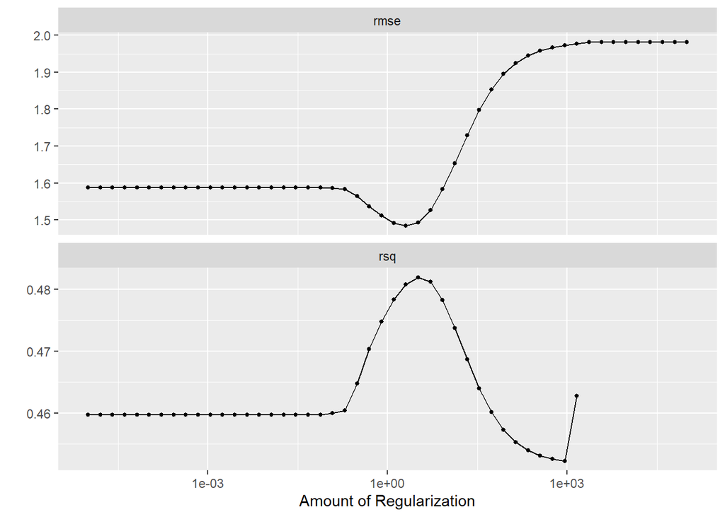

```r
autoplot(tune_res1)
```

```r
best_penalty1 <- select_best(tune_res1, metric = "rsq")

ridge_final <- finalize_workflow(ridge_workflow, best_penalty1)

ridge_final_fit <- fit(ridge_final, data = videogame_train)

augment(ridge_final_fit, new_data = videogame_test) %>%
  rsq(truth = global_sales, estimate = .pred)
```

```
## # A tibble: 1 x 3
##   .metric .estimator .estimate
##   <chr>   <chr>          <dbl>
## 1 rsq     standard       0.535
```

### Lasso Regression

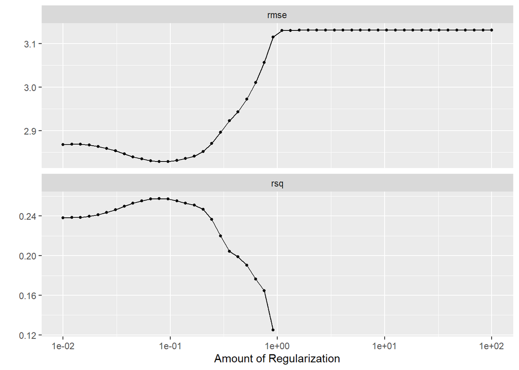

```r
autoplot(tune_res2)
```

```r
best_penalty2 <- select_best(tune_res2, metric = "rsq")

lasso_final <- finalize_workflow(lasso_workflow, best_penalty2)

lasso_final_fit <- fit(lasso_final, data = videogame_train)

augment(ridge_final_fit, new_data = videogame_test) %>%
  rsq(truth = global_sales, estimate = .pred)
```

```
## # A tibble: 1 x 3
##   .metric .estimator .estimate
##   <chr>   <chr>          <dbl>
## 1 rsq     standard       0.535
```